# network analytics

[Home](https://annepu-ram.github.io/)

## Ram Annepu

### Network Analysis

[figure not shown]

# network analytics

seetharam annepu

```r
ifelse(require(igraph),{library("igraph")},install.packages("igraph"))
```

```
## [1] "igraph"
```

```r
ifelse(require(igraphdata),{library("igraphdata")},install.packages("igraphdata"))
```

```
## [1] "igraphdata"
```

```r
ifelse(require(dplyr),{library("dplyr")},install.packages("dplyr"))
```

```
## [1] "dplyr"
```

```r
ifelse(require(tidyr),{library("tidyr")},install.packages("tidyr"))
```

```
## [1] "tidyr"
```

```r
ifelse(require(tmaptools),{library("tmaptools")},install.packages("tmaptools"))
```

```
## [1] "tmaptools"
```

```r
ifelse(require(rworldmap),{library("rworldmap")},install.packages("rworldmap"))
```

```
## ### Welcome to rworldmap ###
```

```
## For a short introduction type :   vignette('rworldmap')
```

```
## [1] "rworldmap"
```

```r
ifelse(require(devtools),{library("devtools")},install.packages("devtools"))
```

```
## [1] "usethis"
```

```r
ifelse(require(lubridate),{library("lubridate")},install.packages("lubridat"))
```

```
## [1] "lubridate"
```

```r
ifelse(require(doBy),{library("doBy")},install.packages("doBy"))
```

```
## [1] "doBy"
```

```r
#devtools::install_github("gsk3/taRifx.geo")
library("ggmap")
```

For this analysis, Divvy data is being used. although i initially did this analysis on flight data, I now wanted to try the analysis on bike sharing data from divvy to learn insights from a different context.

```r
trips<-read.csv(file.choose(),header = T)
trips$start_time<-as.POSIXct(trips$start_time, format="%Y-%m-%d %H:%M:%S")
trips$end_time<-as.POSIXct(trips$end_time, format="%Y-%m-%d %H:%M:%S")
# trips %>%
#   separate(start_time, c("start_date", "start_time"), " ")->trips
# trips %>%
#   separate(start_time, c("end_date", "end_time"), " ")->trips


trips<-trips[months(trips$start_time) %in% month.name[10],]
#connections<-read.csv(file.choose(),header = T)
```

```r
head(trips)
```

```
##    trip_id          start_time            end_time bikeid tripduration
## 1 20983530 2018-10-01 00:01:17 2018-10-01 00:29:35   4551      1,698.0
## 2 20983531 2018-10-01 00:03:59 2018-10-01 00:10:55    847        416.0
## 3 20983532 2018-10-01 00:05:14 2018-10-01 00:14:08   6188        534.0
## 4 20983533 2018-10-01 00:05:48 2018-10-01 00:18:46   6372        778.0
## 5 20983534 2018-10-01 00:07:29 2018-10-01 00:25:51   1927      1,102.0
## 6 20983535 2018-10-01 00:07:36 2018-10-01 00:11:25   2392        229.0
##   from_station_id          from_station_name to_station_id
## 1              85      Michigan Ave & Oak St           166
## 2              13 Wilton Ave & Diversey Pkwy           144
## 3              59  Wabash Ave & Roosevelt Rd           197
## 4             328        Ellis Ave & 58th St           419
## 5              93  Sheffield Ave & Willow St           159
## 6             229  Southport Ave & Roscoe St           318
##                  to_station_name   usertype gender birthyear
## 1   Ashland Ave & Wrightwood Ave Subscriber   Male      1992
## 2      Larrabee St & Webster Ave Subscriber Female      1982
## 3      Michigan Ave & Madison St Subscriber   Male      1986
## 4        Lake Park Ave & 53rd St Subscriber Female      1960
## 5      Claremont Ave & Hirsch St Subscriber Female      1993
## 6 Southport Ave & Irving Park Rd Subscriber   Male      1992
```

```r
#head(connections)
nrow(trips)
```

```
## [1] 344940
```

```r
trips %>% group_by(from_station_id,to_station_id) %>% count(name="trips")->trips_freq
#connections[connections$member1=="220654721",]
#setnames(trips_freq,old="n",new="weight")
trips_freq
```

```
## # A tibble: 50,971 x 3
## # Groups:   from_station_id, to_station_id [50,971]
##    from_station_id to_station_id trips
##              <int>         <int> <int>
##  1               2             2    53
##  2               2             3    34
##  3               2             4     7
##  4               2             5     4
##  5               2             6     7
##  6               2             7     9
##  7               2            14     1
##  8               2            24     1
##  9               2            25     1
## 10               2            26     4
## # ... with 50,961 more rows
```

### its impossible to plot 50K trips on a markdown. But lets give it a try!!!

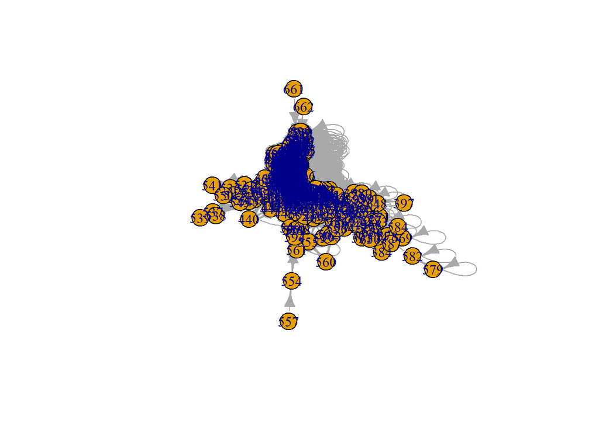

```r
tripsNW <- graph_from_data_frame(trips_freq[,c(1,2)],directed=TRUE)
plot(tripsNW)#,vertex.label=NA)
```

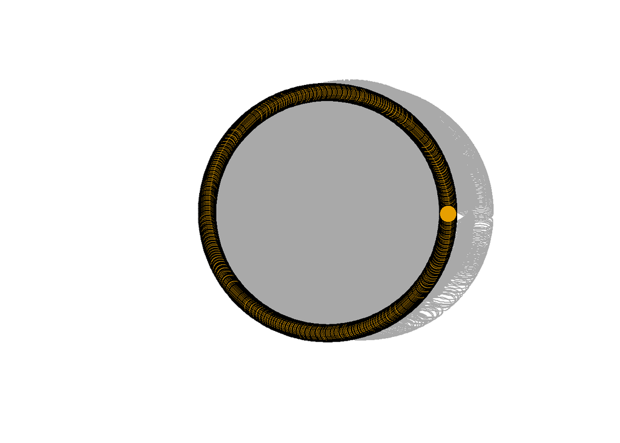

```r
plot(tripsNW,vertex.label=NA,layout=layout_in_circle)
```

we could also try arc diagrams, which are again useless in this case.

### the Node properties are:

Degree centrality: how many other nodes are immediately connected to a node in focus. Closeness Centrality: 1/(sum of distances of all other nodes) betweenness centrality: sigma(for every pair of nodes except the node under consideration)(number of shortest distance that pass through the node under consideration/total number of shortest distances) in simple terms betweenness, centrality and shortest connectivity of a node to all other nodes. intutively these nodes are like hubs in airways shortest distance to all the other nodes for a given paths.

```r
btwns<-betweenness(tripsNW,directed = TRUE)
#sort(btwns, decreasing = TRUE)
length(btwns)
```

```
## [1] 597
```

```r
x<-unique(trips[,c(6,7)])

btwnness.df<-as.data.frame(stack(sort(btwns, decreasing = TRUE)))
names(btwnness.df)[2]<-"area_code"
rownames(btwnness.df) <- 1:nrow(btwnness.df) #reset index because we have changed the old index to column
x[[1]]<-as.character(x$from_station_id)
btwnness.df$area_code<-as.character(btwnness.df$area_code)
btwnness.df %>% left_join(x,by = c("area_code" = "from_station_id")) -> btwnness.df.names
btwnness.df.names%>%arrange(desc(values))
```

```
##          values area_code                           from_station_name
## 1   8230.889146       211                      St. Clair St & Erie St
## 2   8089.006798        35                     Streeter Dr & Grand Ave
## 3   6052.682669       424              Museum of Science and Industry
## 4   5101.410378        90                             Millennium Park
## 5   4951.041478        11                      Jeffery Blvd & 71st St
## 6   4795.228953       429                 Cottage Grove Ave & 67th St
## 7   4708.181813       247                          Shore Dr & 55th St
## 8   4662.264716       392                         Perry Ave & 69th St
## 9   4019.989523        44                      State St & Randolph St
## 10  4001.390748       283                   LaSalle St & Jackson Blvd
## 11  3995.798026        69                      Damen Ave & Pierce Ave
## 12  3667.227487       585                 Cottage Grove Ave & 83rd St
## 13  3625.341667       388                        Halsted St & 63rd St
## 14  3603.723551        75                     Canal St & Jackson Blvd
```

[output cut: 583 more lines]

```r
nrow(btwnness.df.names)
```

```
## [1] 597
```

lets geocode and see what inbetweenness represent in this context of brike sharing service on a map.

```r
btwnness.df.names$from_station_name <- paste0(btwnness.df.names$from_station_name, ", chicago, illinois, united states")

register_google(key = "MY_KEY")

geodata_1<-mutate_geocode(btwnness.df.names,from_station_name)

#geodata_2<-geocodeVect(btwnness.df.names$from_station_name[401:597], service="bing", returntype="coordinates")
```

```r
chicago<-get_map("Chicago",zoom = 11)
```

[figure not shown]

```r
 ggmap(chicago)+
geom_point(data = geodata_1[1:200,], aes(x = lon, y = lat), color = 'blue', size = 2,alpha=0.5)+
   geom_point(data = geodata_1[400:597,], aes(x = lon, y = lat), color = 'red', size = 2,alpha=0.5)
```

now lets analyse places that have high inbetweenness and analyse the time and day of the rides at these places.

```r
trips$from_station_id<-as.character(trips$from_station_id)
trips$to_station_id<-as.character(trips$to_station_id)
names(btwnness.df)[2]<-"station_id"
btwnness.df[1:100,]%>%inner_join(trips,by=c("station_id"="from_station_id"))->trips_btwnss_top100
btwnness.df[498:597,]%>%inner_join(trips,by=c("station_id"="from_station_id"))->trips_btwnss_bottom100
btwnness.df[1:100,]%>%inner_join(trips,by=c("station_id"="to_station_id"))->trips_btwnss_top100_to
btwnness.df[498:597,]%>%inner_join(trips,by=c("station_id"="to_station_id"))->trips_btwnss_bottom100_to
nrow(trips_btwnss_top100)
```

```
## [1] 133125
```

```r
nrow(trips_btwnss_bottom100)
```

```
## [1] 4168
```

```r
nrow(trips_btwnss_top100_to)
```

```
## [1] 132387
```

```r
nrow(trips_btwnss_bottom100_to)
```

```
## [1] 4352
```

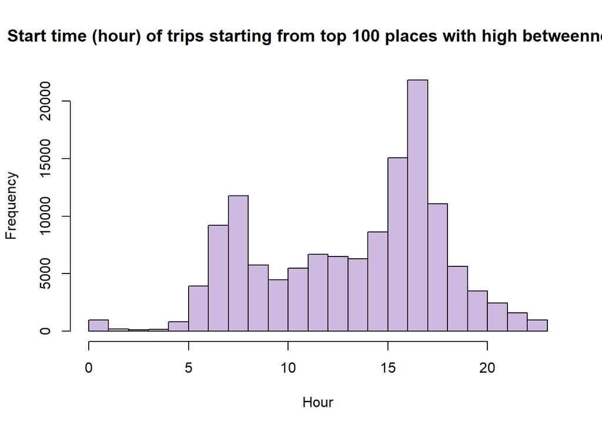

```r
Hour <- as.POSIXlt(trips_btwnss_top100$start_time)$hour
hist(Hour, breaks=seq(0, 23), main="Start time (hour) of trips starting from top 100 places with high betweenness",col="#CEBADF")
```

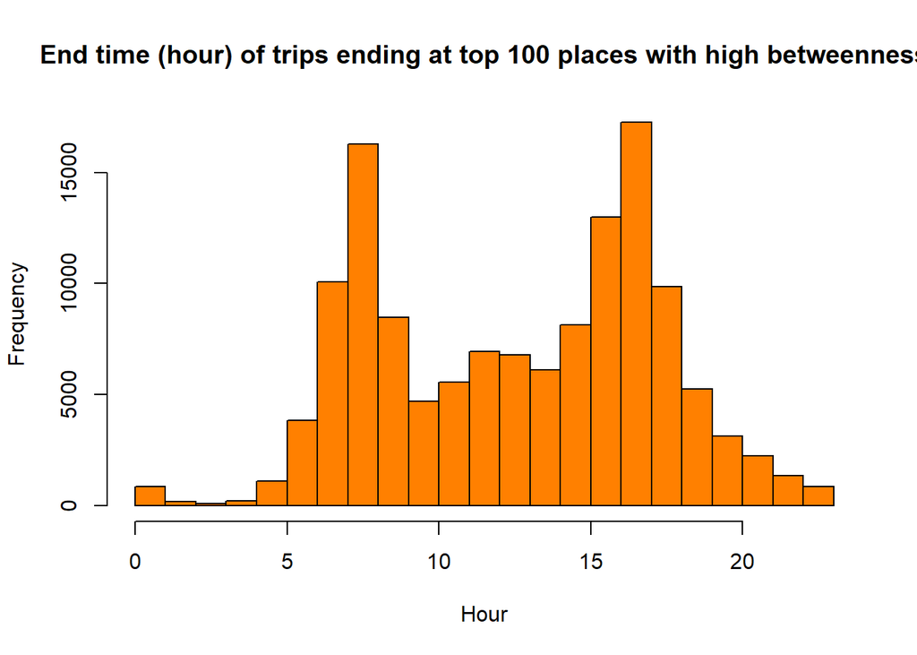

```r
Hour <- as.POSIXlt(trips_btwnss_top100_to$end_time)$hour
hist(Hour, breaks=seq(0, 23), main="End time (hour) of trips ending at top 100 places with high betweenness",col="#FF8000FF")
```

the peak hours are obviously 7-8AM and 4-5PM, because these could be the work related commute hours. on further analysis, we find that trips starting from these places are fewer than the trips ending at these places in the morning. we can surmise that these bike stations are close to work places. And, from the map plot we can infer that these places are at the heart of city and we see more demand at these places. furthermore, people starting from these places are more in the evening then in the morning.

[figure not shown]

```r
Hour <- as.POSIXlt(trips_btwnss_bottom100$start_time)$hour
hist(Hour, breaks=seq(0, 23), main="start time (hour) of trips from bottom 100 places with high betweenness",col="#AABADF")
```

[figure not shown]

```r
Hour <- as.POSIXlt(trips_btwnss_bottom100_to$end_time)$hour
hist(Hour, breaks=seq(0, 23), main="end time (hour) of trips to bottom 100 places with low betweenness", col="#FF9007AA")
```

when above graphs are compared with the previous graphs, a reverse patern will be very evident. in these graphs, the trips to these places in the evening hours are more than in the morning hour. also the demand is much less in thse places.

```r
tym_diff <- (trips_btwnss_top100$end_time- trips_btwnss_top100$start_time)
units(tym_diff)<-"mins"
sum(tym_diff>360)
```

```
## [1] 194
```

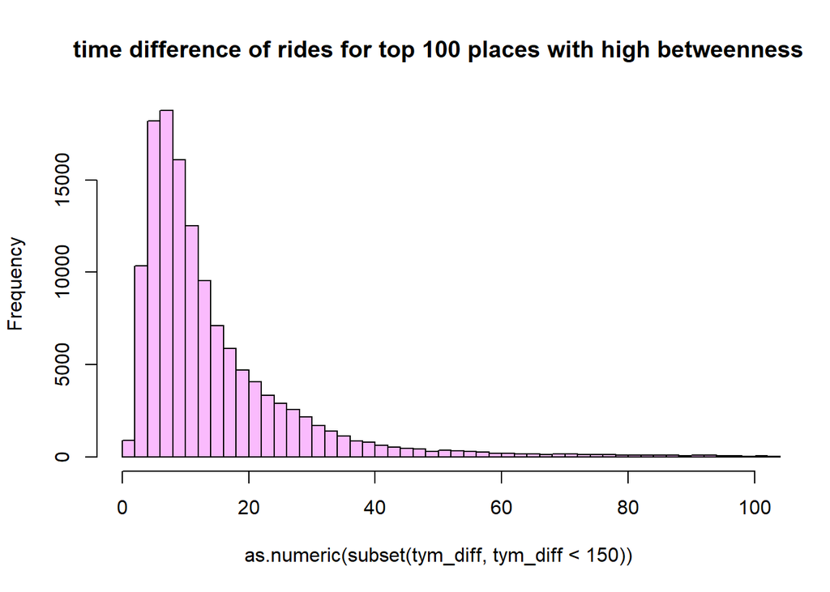

```r
hist(as.numeric(subset(tym_diff,tym_diff<150)),seq(0,150,2),xlim=c(0,100), main="time difference of rides for top 100 places with high betweenness",col="#FABBFD")
```

Above graph shows the duration histogram of the rides, which could be used to design a pricing model.

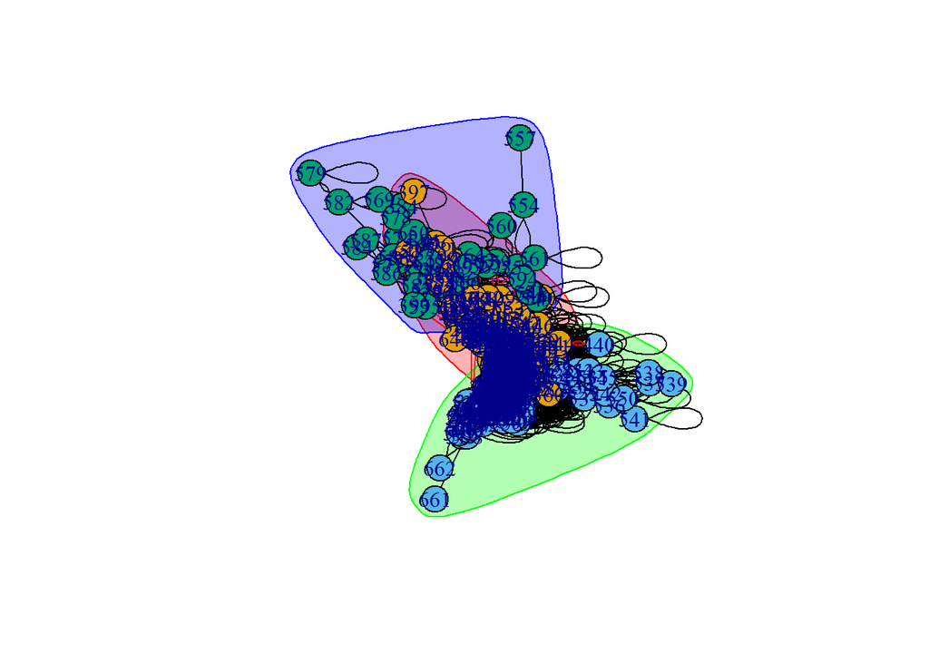

```r
#arpack_options.maxiter=3000000
tripsNWUD <- graph_from_data_frame(trips_freq[,c(1,2)],directed=FALSE)
graph <- simplify(tripsNWUD)
communities<-fastgreedy.community(graph)

plot(communities,tripsNWUD)#,vertex.label=NA)
```

network properties: shortest path diameter of the network density cluster coeffient Communities: there are three algorithmns to find community: greedy method edge inbetweennes eigen vector

what are communities: communities are densely connected sub-networks in the parent network. in our case we used greedy algorithm, which is based on increase in modularity of sub-network at each increment of the node in the subnetwork until the modularity remains unchanged for any subsequent additi of node.

For this data-set we obtained 3 communities

```r
length(unique(communities$names))
```

```
## [1] 597
```

```r
max(communities$membership)
```

```
## [1] 3
```

```r
subset(communities$names,communities$membership ==3)
```

```
##  [1] "384" "386" "388" "391" "392" "395" "400" "430" "549" "551" "554"
## [12] "555" "557" "559" "560" "561" "562" "563" "564" "566" "567" "568"
## [23] "569" "570" "571" "572" "573" "574" "575" "577" "578" "579" "582"
## [34] "583" "584" "585" "586" "587" "593" "594" "595" "649" "650" "393"
```

```r
#lets map these communities
#subset(communities$names,communities$membership ==3)%>% left_join(geodata_1,)
geodata_1[geodata_1$area_code %in% subset(communities$names,communities$membership ==1),]->c1
geodata_1[geodata_1$area_code %in% subset(communities$names,communities$membership ==2),]->c2
geodata_1[geodata_1$area_code %in% subset(communities$names,communities$membership ==3),]->c3
```

[figure not shown]

```r
ggmap(chicago, scale=2 )+geom_point(data =c1, aes(x = lon, y = lat), color = 'blue', size = 1,alpha=0.5)+
   geom_point(data = c2, aes(x = lon, y = lat), color = 'red', size = 1,alpha=0.5)+
  geom_point(data = c3, aes(x = lon, y = lat), color = 'orange', size = 1,alpha=1)
```

seems like, here, communities represent various neighborhoods: residential neighbourhood (red dots) such as lake view, lincoln park and edison park, which is moderately traversed by these bikers; the well travelled commercial area (blue dots) of chicago and the southern chicago, which seems to be the least traversed parts.

```r
node.prop.df<-NULL
Clust_network<-graph.edgelist(as.matrix(trips[,c(6,8)]), directed=TRUE)
indegree <- degree(Clust_network,mode="in")

outdegree <- degree(Clust_network,mode="out")

closeness_in <- closeness(Clust_network, mode="in",normalized = TRUE)
btwn <- betweenness(Clust_network,normalized = TRUE)
pg_rank <- page_rank(Clust_network,damping = 0)
eigenv <- eigen_centrality(Clust_network, directed = TRUE, scale = T)

df<-data.frame(stations=names(indegree),indegree=indegree)
row.names(df)<-1:nrow(df)
df<-merge(df, data.frame(stations=names(outdegree),outdegree=outdegree), by = "stations")
df<-merge(df, data.frame(stations=names(closeness_in),closeness_in=closeness_in), by = "stations")
df<-merge(df, data.frame(stations=names(btwn),betweenness=btwn), by = "stations")
#df<-merge(df, data.frame(stations=names(eigenv$vector),eigen_values=eigenv$vector), by = "stations") ##########eigen centrality is irrelevant here
node.prop.df<-df
head(node.prop.df)
```

```
##   stations indegree outdegree closeness_in  betweenness
## 1      100     2401      3336    0.1708226 5.777492e-03
## 2      101       54        59    0.1555730 1.492470e-03
## 3      102       14         9    0.1430972 5.729107e-05
## 4      103      277       244    0.1609941 1.597724e-05
## 5      106     1021      1093    0.1681716 1.486740e-03
## 6      107     1503      1509    0.1702371 9.153928e-03
```

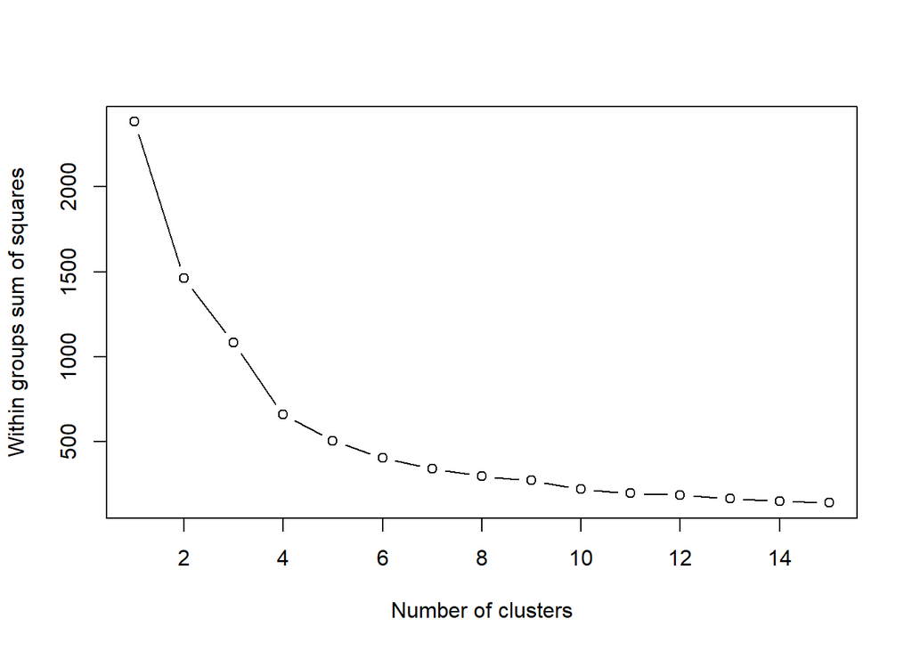

```r
normalized_data<-scale(node.prop.df[,2:5])
Cluster_Variability <- matrix(nrow=15, ncol=1)
for (i in 1:15) Cluster_Variability[i]<- kmeans(normalized_data[] ,centers=i, nstart=i)$tot.withinss
plot(1:15, Cluster_Variability, type="b", xlab="Number of clusters", ylab="Within groups sum of squares")
```

```r
fit<- kmeans(normalized_data, centers=4, iter.max=50, nstart=9)
node.prop.df <- cbind(node.prop.df, fit$cluster)
head(node.prop.df)
```

```
##   stations indegree outdegree closeness_in  betweenness fit$cluster
## 1      100     2401      3336    0.1708226 5.777492e-03           3
## 2      101       54        59    0.1555730 1.492470e-03           1
## 3      102       14         9    0.1430972 5.729107e-05           1
## 4      103      277       244    0.1609941 1.597724e-05           1
## 5      106     1021      1093    0.1681716 1.486740e-03           3
## 6      107     1503      1509    0.1702371 9.153928e-03           3
```

```r
summaryBy(indegree~`fit$cluster`, data = node.prop.df,
          FUN = list(mean))
```

```
##   fit$cluster indegree.mean
## 1           1   235.0682353
## 2           2  3792.5384615
## 3           3  1304.8333333
## 4           4     0.8888889
```

```r
summaryBy(outdegree~`fit$cluster`, data = node.prop.df,
          FUN = list(mean))
```

```
##   fit$cluster outdegree.mean
## 1           1     231.771765
## 2           2    3864.076923
## 3           3    1307.900000
## 4           4       2.111111
```

```r
summaryBy(closeness_in~`fit$cluster`, data = node.prop.df,
          FUN = list(mean))
```

```
##   fit$cluster closeness_in.mean
## 1           1       0.155081925
## 2           2       0.172212139
## 3           3       0.168160211
## 4           4       0.001675666
```

```r
summaryBy(betweenness~`fit$cluster`, data = node.prop.df,
          FUN = list(mean))
```

```
##   fit$cluster betweenness.mean
## 1           1     0.0012194900
## 2           2     0.0168514567
## 3           3     0.0038910413
## 4           4     0.0001842348
```

stations in clusters with high in-degree and out-degree should be closely monitored for number of available bikes to maitain service quality.